# Visualization (ggplot2, matplotlib, & seaborn)

## Layering

Calls to axes-level functions on the same `Axes` stack, so layers are built by calling functions in order (each draws immediately) rather than by adding them to a plot object. Each layer with `hue` would replace the legend with its own, so later layers pass `legend=False`.

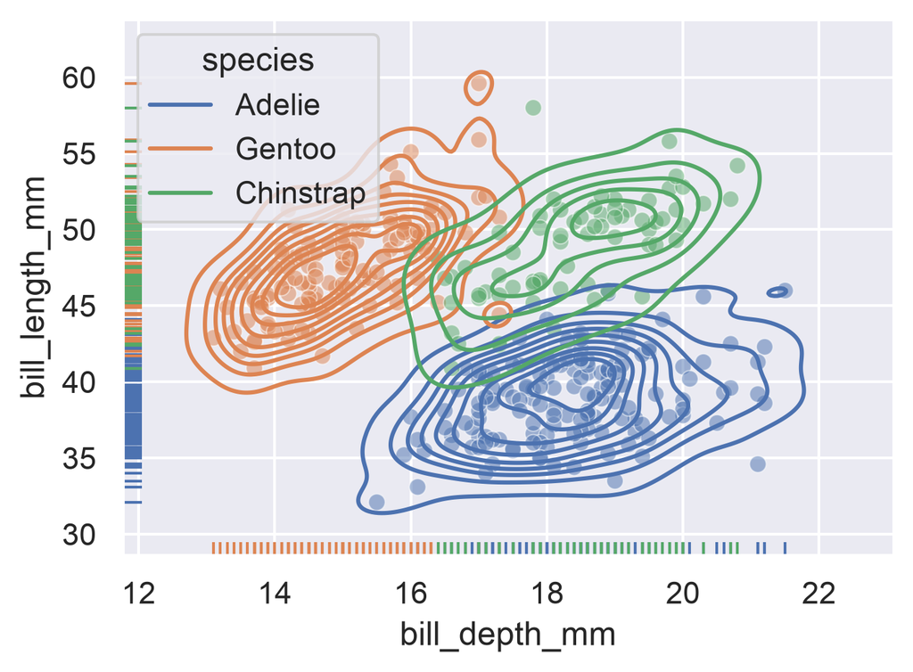

```python
fig, ax = plt.subplots(figsize=(5, 3.5))
sns.kdeplot(
  data=penguins, x="bill_depth_mm",
  y="bill_length_mm", hue="species",
  ax=ax
)
sns.scatterplot(
  data=penguins, x="bill_depth_mm",
  y="bill_length_mm", hue="species",
  alpha=0.5, legend=False, ax=ax
)
sns.rugplot(
  data=penguins, x="bill_depth_mm",
  y="bill_length_mm", hue="species",
  legend=False, ax=ax
)
```

## Figure-level or axes-level?

### Figure-level functions

- facet by data variables with `col=` and `row=`
- legend outside the plot by default
- `kind=` switches the representation without changing the call
- sized per facet with `height` and `aspect`
- many options are not in the signature but pass through as `**kwargs`

### Axes-level functions

- drop into any matplotlib figure with `ax=`, so they compose with subplots and plain matplotlib
- plot-specific parameters appear in the signature; additional matplotlib options pass through `**kwargs`
- sized like any matplotlib figure with `figsize`
- the choice when the plot is one panel of something larger

Based on the [function overview](https://seaborn.pydata.org/tutorial/function_overview.html) in the seaborn docs.

## Themes and palettes

`sns.set_theme()` sets the `style` (`darkgrid`, `whitegrid`, `dark`, `white`, `ticks`), the `context` (`paper`, `notebook`, `talk`, `poster`, which scale fonts and line widths), and the default `palette` for every subsequent figure. `palette=` on any function applies to one plot and `with sns.axes_style("white"):` to a block.

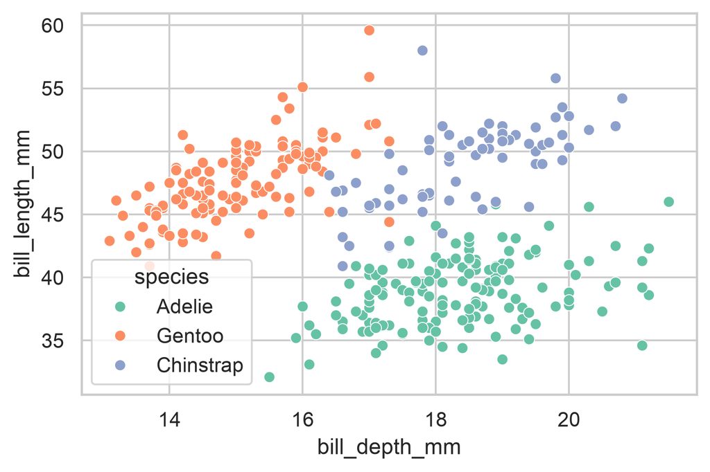

```python
sns.set_theme(
  style="whitegrid", palette="Set2"
)
sns.scatterplot(
  data=penguins, x="bill_depth_mm",
  y="bill_length_mm", hue="species"
)
```

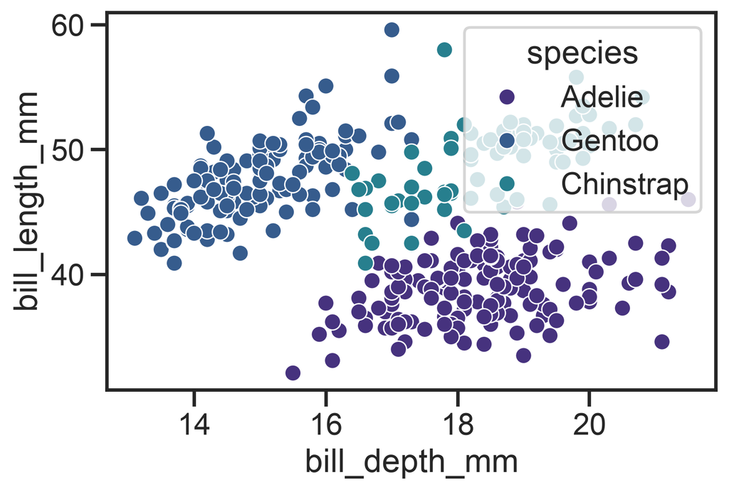

```python
sns.set_theme(
  style="ticks", context="talk", palette="viridis"
)
sns.scatterplot(
  data=penguins, x="bill_depth_mm",
  y="bill_length_mm", hue="species"
)
```

# seaborn.objects

## `seaborn.objects`

> The `seaborn.objects` namespace was introduced in version 0.12 as a completely new interface for making seaborn plots. … the new interface aims to support end-to-end plot specification and customization without dropping down to matplotlib (although it will remain possible to do so if necessary).

```python
import seaborn.objects as so
```

This is seaborn’s take on the grammar of graphics.

A `Plot` holds the data and mappings, each `.add()` is a layer combining a `Mark` (`Dot`, `Line`, `Bar`, `Area`, …) with an optional `Stat` (`Agg`, `Hist`, `PolyFit`, …) and `Move` (`Dodge`, `Jitter`, `Stack`, …), and `.facet()`, `.scale()`, `.label()`, and `.theme()` apply to the whole plot.

A `Plot` is a specification that is rendered by `.show()`, `.plot()`, or `.save()`, or automatically when displayed in a Jupyter notebook.

The objects interface is still marked as under development and covers less than ggplot2 (no polar coordinates, fewer marks); the classic interfaces are not going away.

## Building a plot

`so.Plot()` takes the data and the mappings; `.add()` adds a layer, and a mark with no stat draws the data as is.

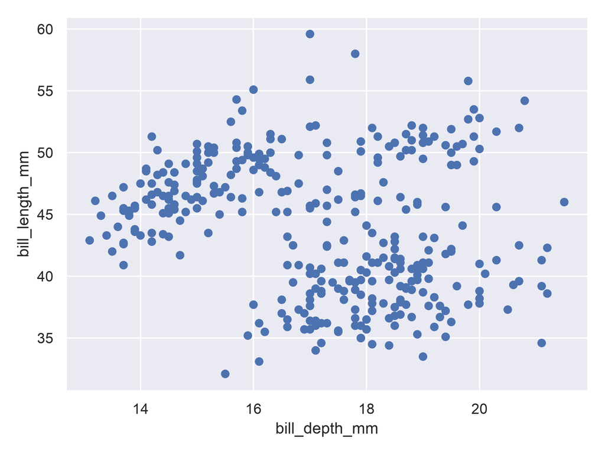

```python
( so.Plot(
    penguins,
    x="bill_depth_mm",
    y="bill_length_mm"
  )
  .add(so.Dot())
).show()
```

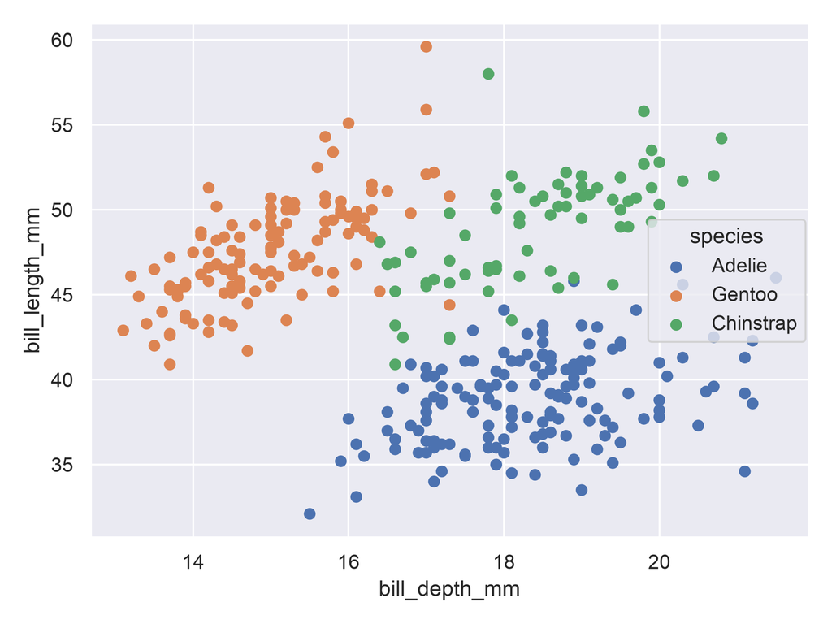

```python
( so.Plot(
    penguins,
    x="bill_depth_mm",
    y="bill_length_mm",
    color="species"
  )
  .add(so.Dot())
).show()
```

## Layers and stats

Each `.add()` is a layer; a `Stat` passed with the mark transforms the data before it is drawn, per group when a mapping such as `color` is present.

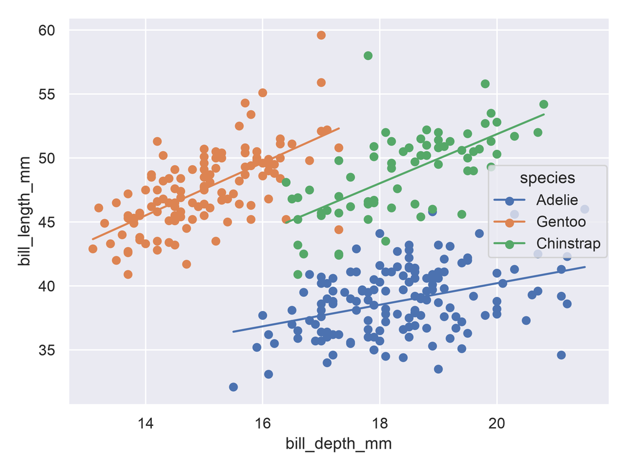

```python
( so.Plot(
    penguins,
    x="bill_depth_mm",
    y="bill_length_mm",
    color="species"
  )
  .add(so.Dot())
  .add(so.Line(), so.PolyFit(order=1))
).show()
```

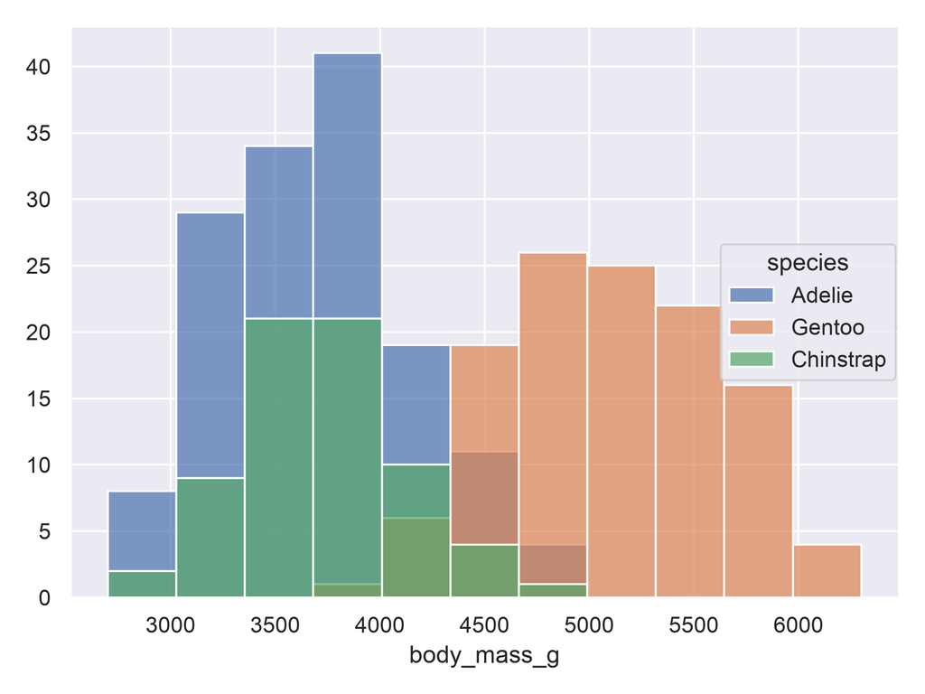

```python
( so.Plot(
    penguins,
    x="body_mass_g", color="species"
  )
  .add(so.Bars(), so.Hist())
).show()
```

## Facets, scales, and labels

The remaining methods are plot-wide, mirroring the last step of the ggplot2 example.

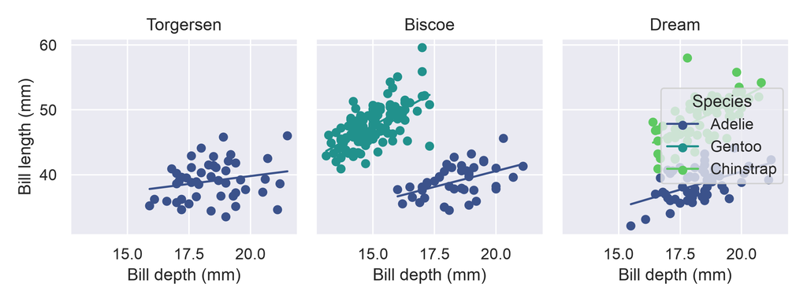

```python
( so.Plot(
    penguins, x="bill_depth_mm", y="bill_length_mm", color="species"
  )
  .add(so.Dot())
  .add(so.Line(), so.PolyFit(order=1))
  .facet(col="island")
  .scale(color="viridis")
  .label(x="Bill depth (mm)", y="Bill length (mm)", color="Species")
  .layout(size=(8, 3))
).show()
```

## Moves

A `Move` adjusts positions after the stat: `Dodge()` places groups side by side, `Jitter()` spreads overlapping points, `Stack()` piles them up.

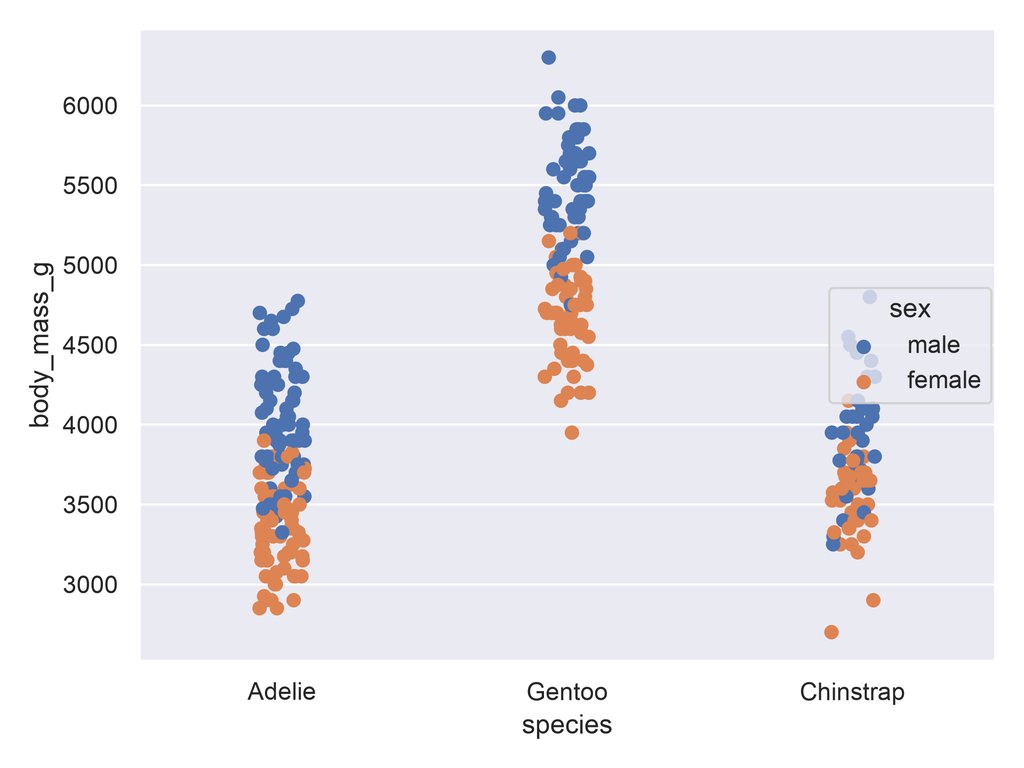

```python
( so.Plot(
    penguins,
    x="species", y="body_mass_g",
    color="sex"
  )
  .add(so.Dot(), so.Jitter())
).show()
```

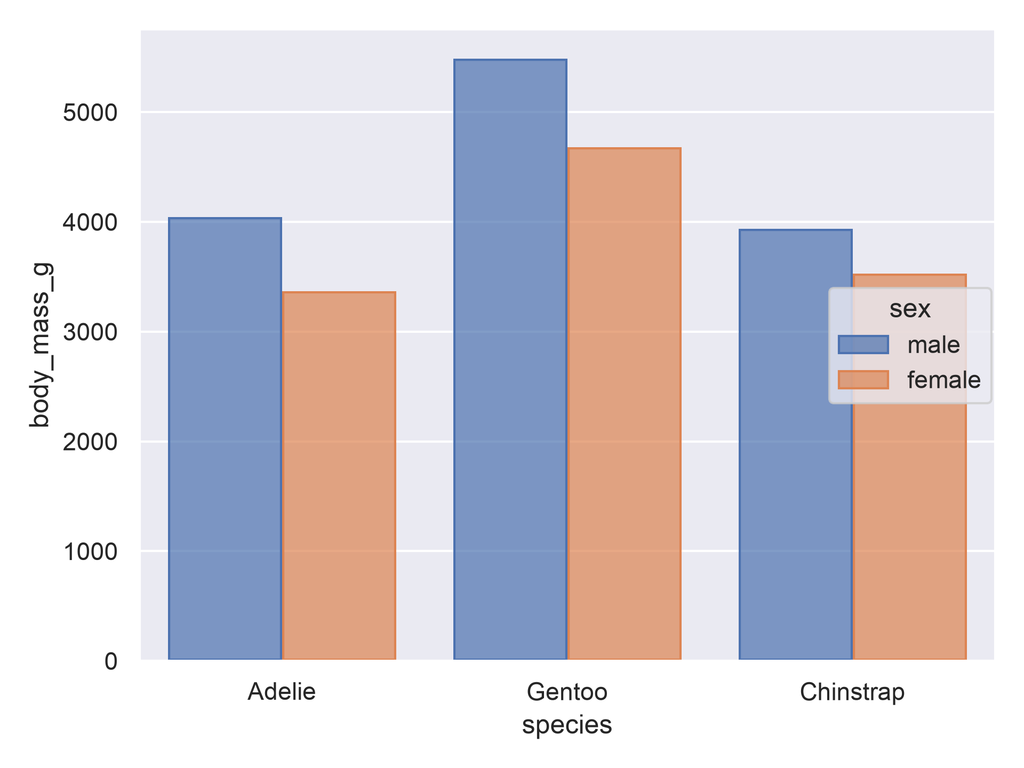

```python
( so.Plot(
    penguins,
    x="species", y="body_mass_g",
    color="sex"
  )
  .add(so.Bar(), so.Agg(), so.Dodge())
).show()
```

## ggplot2 to `seaborn.objects`

| ggplot2 | seaborn.objects |
| --- | --- |
| `ggplot(data, aes(x, y, color))` | `so.Plot(data, x=, y=, color=)` |
| `+ geom_point()`, `+ geom_line()` | `.add(so.Dot())`, `.add(so.Line())` |
| `+ geom_bar()` | `.add(so.Bar(), so.Count())` |
| `+ geom_histogram()` | `.add(so.Bars(), so.Hist())` |
| `+ geom_smooth(method = "lm", se = FALSE)` | `.add(so.Line(), so.PolyFit(order=1))` |
| `+ stat_summary(fun = mean, geom = "point")` | `.add(so.Dot(), so.Agg())` |
| `position = "dodge"`, `"jitter"`, `"stack"` | `so.Dodge()`, `so.Jitter()`, `so.Stack()` |
| `+ facet_wrap(~ v)`, `+ facet_grid(r ~ c)` | `.facet(col="v", wrap=)`, `.facet(row=, col=)` |
| `+ scale_color_viridis_d()` | `.scale(color="viridis")` |
| `+ labs()` | `.label()` |
| `+ coord_cartesian(xlim = )` | `.limit(x=)` |
| `+ theme()` | `.theme({...})` with matplotlib rcParams |
| `ggsave()` | `.save()` |
| printing the object | `.show()` |

# Summary

## Takeaways

- A plot is data, mappings from variables to aesthetics, and layers (geom + stat + position) drawn on shared scales, facets, and coordinates under a theme. ggplot2 is this grammar; `seaborn.objects` is its closest Python analog.
- matplotlib is the drawing layer beneath seaborn, plotnine, and pandas’ default plotting backend. Know `Figure`, `Axes`, and `Axis`, the `plt.f()` to `ax.set_f()` naming, and prefer the object-oriented style.
- seaborn’s figure-level functions create and manage a figure; axes-level functions draw on an `Axes` supplied through `ax=`. `relplot()`, `displot()`, and `catplot()` select plot types with `kind=`; `lmplot()` provides regression plots. All four support faceting and return a `FacetGrid`. `x`, `y`, `hue`, `size`, and `style` are aesthetic mappings; keywords such as `color=` are settings.
- Use whichever gets to the plot in the fewest concepts, and drop down to matplotlib for the last details.

## Learning more

ggplot2

- [Reference](https://ggplot2.tidyverse.org/reference/)
- [ggplot2 book](https://ggplot2-book.org/)
- [R4DS - Visualize](https://r4ds.hadley.nz/visualize.html)
- [Extension gallery](https://exts.ggplot2.tidyverse.org/gallery/)

matplotlib

- [Quick start guide](https://matplotlib.org/stable/users/explain/quick_start.html)
- [Plot types](https://matplotlib.org/stable/plot_types/)
- [Cheatsheets](https://matplotlib.org/cheatsheets/)

seaborn & plotnine

- [User guide](https://seaborn.pydata.org/tutorial.html)
- [API reference](https://seaborn.pydata.org/api.html)
- [Example gallery](https://seaborn.pydata.org/examples/index.html)
- [The objects interface](https://seaborn.pydata.org/tutorial/objects_interface.html)
- [plotnine](https://plotnine.org/), ggplot2 in Python

For what to plot rather than how: [Fundamentals of Data Visualization](https://clauswilke.com/dataviz/) (Wilke) and [Data Visualization: A Practical Introduction](https://socviz.co/) (Healy).

# Reference

## Naming conventions

Every `plt.*` function acts on the current Figure or Axes; the object-oriented equivalents are methods of `Figure` or `Axes`, with setters named `set_*()` (and matching `get_*()`).

| pyplot (current figure / axes) | object-oriented |
| --- | --- |
| `plt.figure()`, `plt.subplots()` | `fig = plt.figure()`, `fig, ax = plt.subplots()` |
| `plt.plot()`, `plt.scatter()`, `plt.hist()`, `plt.bar()` | `ax.plot()`, `ax.scatter()`, `ax.hist()`, `ax.bar()` |
| `plt.title()` | `ax.set_title()` |
| `plt.xlabel()`, `plt.ylabel()` | `ax.set_xlabel()`, `ax.set_ylabel()` |
| `plt.xlim()`, `plt.ylim()` | `ax.set_xlim()`, `ax.set_ylim()` |
| `plt.xscale()`, `plt.yscale()` | `ax.set_xscale()`, `ax.set_yscale()` |
| `plt.xticks()`, `plt.yticks()` | `ax.set_xticks()`, `ax.set_xticklabels()`, … |
| `plt.legend()`, `plt.grid()` | `ax.legend()`, `ax.grid()` |
| `plt.suptitle()`, `plt.savefig()` | `fig.suptitle()`, `fig.savefig()` |
| `plt.gcf()`, `plt.gca()` | `fig`, `ax` |

`ax.set(title=, xlabel=, xlim=, ...)` sets several properties in one call.

## The `FacetGrid`

The figure-level functions covered here return a `FacetGrid`, a wrapper around the matplotlib `Figure` and its `Axes` that also manages the legend and the facet titles.

```python
type(g)
```

```
<class 'seaborn.axisgrid.FacetGrid'>
```

| Attribute | Description |
| --- | --- |
| `figure` | the matplotlib `Figure` |
| `ax` | the `Axes`, when there is a single facet |
| `axes` | array of `Axes`, one per facet |
| `axes_dict` | facet name(s) to `Axes` |
| `legend` | the `Legend`, if there is one |

| Method | Description |
| --- | --- |
| `set_axis_labels()` | x and y labels on the outer facets |
| `set_titles()` | facet titles from a template, e.g. `"{col_name}"` |
| `set()` | call `Axes.set()` on every facet |
| `refline()` | add reference lines to every facet |
| `map()` | apply a plotting function to every facet |
| `savefig()` | save the figure |

## Vocabulary

| Concept | ggplot2 | matplotlib | seaborn | seaborn.objects |
| --- | --- | --- | --- | --- |
| data | `ggplot(data)` | arrays or `data=` | `data=` | `so.Plot(data)` |
| mapping | `aes(color = v)` | a loop over groups | `hue="v"`, `size=`, `style=` | `color="v"`, `pointsize=` |
| setting | `color = "red"` | `color="red"` | `color="red"` | `so.Dot(color="red")` |
| geom | `geom_*()` | `ax.scatter()`, `ax.plot()`, … | `kind=` or an axes-level function | `so.Dot()`, `so.Bar()`, … |
| stat | `stat_*()` | by hand | built into each function | `so.Hist()`, `so.Agg()`, … |
| position | `position =` | by hand | `dodge=`, `multiple=` | `so.Dodge()`, `so.Stack()` |
| facets | `facet_wrap()` | `plt.subplots()` | `col=`, `row=` | `.facet()` |
| scales | `scale_*()` | `ax.set_xscale()`, colormaps | `palette=`, `hue_norm=` | `.scale()` |
| labels | `labs()` | `ax.set_xlabel()`, `ax.set_title()` | `g.set_axis_labels()` | `.label()` |
| theme | `theme_*()`, `theme()` | rcParams, style sheets | `sns.set_theme()` | `.theme()` |
| object | `ggplot` | `Figure`, `Axes` | `FacetGrid` or `Axes` | `Plot` |
| save | `ggsave()` | `fig.savefig()` | `g.savefig()`, `fig.savefig()` | `.save()` |